# ANOVA_studenci

Magda G.

9 sierpnia 2018

## ANOVA

Niedokładność jako procedury statystycznej, kierowanie sie w stronę mix-modelling.

ANOVA to tosunkowo prosta metoda, ale często wyniki są źle przedstawione i/lub źle zinterpretowane. Czzęsto jest to spowodowane koniecznościa przekopiowywania danych z programów statystycznych. Pakiet ‘psycho’ automatyzuje część czynności i przedstawia wyniki w formie łatwego do przeklejenia tekstu. Pakiet R ‘psycho’

Sprawdzanie jakości danych statystycznych w artykułach http://statcheck.io/. Wymaga podania danych w formacie APA.

[figure not shown]

format APA dla artykułów naukowych Microsoft office umożliwia pobranie template makiety stylu?? “APA style report (6th edition)”

Let’s start by doing a traditional ANOVA with adjusting (the ability to flexibly regulate one’s emotions) as dependent variable, and sex and salary as categorical predictors.

```r
# if needed instal 'psycho'
# install.packages('psycho')
library(psycho)
# if instalation does not work try:
# install.packages('devtools')
# Install the latest psycho version
# devtools::install_github("neuropsychology/psycho.R")

data <- psycho::affective  # load a dataset available in the psycho package
aov_results <- aov(Adjusting ~ Sex * Salary, data=data) # Fit the ANOVA
summary(aov_results)  # Inspect the results
```

```
##              Df Sum Sq Mean Sq F value   Pr(>F)
## Sex           1   35.9   35.94  18.162 2.25e-05 ***
## Salary        2    9.4    4.70   2.376   0.0936 .
## Sex:Salary    2    3.0    1.51   0.761   0.4674
## Residuals   859 1699.9    1.98
## ---
## Signif. codes:  0 '***' 0.001 '**' 0.01 '*' 0.05 '.' 0.1 ' ' 1
## 386 observations deleted due to missingness
```

The psycho package include a simple function, analyze() that can be applied to an ANOVA object to format its content.

```r
analyze(aov_results)
```

```
##    - The effect of Sex is significant (F(1, 859) = 18.16, p < .001) and can be considered as small (Partial Omega-squared = 0.019).
##    - The effect of Salary is not significant (F(2, 859) = 2.38, p = 0.09°) and can be considered as very small (Partial Omega-squared = 0.0032).
##    - The interaction between Sex and Salary is not significant (F(2, 859) = 0.76, p > .1) and can be considered as very small (Partial Omega-squared = 0).
```

It formats the results, computes the partial omega-squared as an index of effect size as well as its interpretation and presents the results in a APA-compatible way.

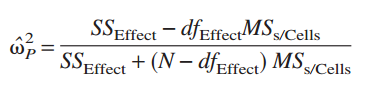

Omega squared (ω2) is a measure of effect size, or the degree of association for a population. It is an estimate of how much variance in the response variables are accounted for by the explanatory variables. Omega squared is widely viewed as a lesser biased alternative to eta-squared, especially when sample sizes are small. ω2 can have values between ± 1; Zero indicates no effect; If the observed F is less than one, ω2 will be negative.

```r
library(tidyverse)
df <- psycho::emotion %>%
  select(Participant_ID,
         Participant_Sex,
         Emotion_Condition,
         Subjective_Valence,
         Recall)

summary(df)
```

```
##  Participant_ID Participant_Sex Emotion_Condition Subjective_Valence
##  10S    : 48    Female:720      Negative:456      Min.   :-100.000
##  11S    : 48    Male  :192      Neutral :456      1st Qu.: -65.104
##  12S    : 48                                      Median :  -2.604
##  13S    : 48                                      Mean   : -18.900
##  14S    : 48                                      3rd Qu.:   7.000
##  15S    : 48                                      Max.   : 100.000
##  (Other):624
##    Recall
##  Mode :logical
##  FALSE:600
##  TRUE :312
##
##
##
##
```

Df zawiera dla każdego powtórzenia 5 zmiennych: imię uczestnika (Participant_ID), płeć (Participant_Sex), emocje (Emotion_Condition), ocenę subiektywną (Subjective_Valence) i czy obraz został zapamiętany (Recall).

### Czy emocje wpływają na ocene subiektywną?

#### Zastosowanie ANOVA

```r
summary(aov(Subjective_Valence ~ Emotion_Condition + Error(Participant_ID/Emotion_Condition), data=df))
```

```
##
## Error: Participant_ID
##           Df Sum Sq Mean Sq F value Pr(>F)
## Residuals 18 115474    6415
##
## Error: Participant_ID:Emotion_Condition
##                   Df  Sum Sq Mean Sq F value   Pr(>F)
## Emotion_Condition  1 1278417 1278417   245.9 6.11e-12 ***
## Residuals         18   93573    5198
## ---
## Signif. codes:  0 '***' 0.001 '**' 0.01 '*' 0.05 '.' 0.1 ' ' 1
##
## Error: Within
##            Df Sum Sq Mean Sq F value Pr(>F)
## Residuals 874 935646    1070
```

Wow, we found that there is a significant effect of the emotional condition on valence ratings. We might have Science material here.

As you know, an ANOVA is pretty much a condensed linear model where the predictors are factors. Therefore, we can run an ANOVA on a linear mixed model (which includes the “error” term, or random effect).

#### Zastosowanie modeli liniowych

```r
library(lmerTest)
fit <- lmer(Subjective_Valence ~ Emotion_Condition + (1|Participant_ID), data=df)
anova(fit)
```

```
## Type III Analysis of Variance Table with Satterthwaite's method
##                    Sum Sq Mean Sq NumDF DenDF F value    Pr(>F)
## Emotion_Condition 1278417 1278417     1   892    1108 < 2.2e-16 ***
## ---
## Signif. codes:  0 '***' 0.001 '**' 0.01 '*' 0.05 '.' 0.1 ' ' 1
```

As you can see, the results are, for the important bits (the sum of squares, mean square and p value), very close to those of the traditional approach.

This function overloads lmer from the lme4-package (lme4::lmer) and adds a couple of slots needed for the computation of Satterthwaite denominator degrees of freedom. All arguments are the same as for lme4::lmer and all the usual lmer-methods work.

a two-sided linear formula object describing both the fixed-effects and random-effects part of the model, with the response on the left of a ~ operator and the terms, separated by + operators, on the right. Random-effects terms are distinguished by vertical bars (|) separating expressions for design matrices from grouping factors. Two vertical bars (||) can be used to specify multiple uncorrelated random effects for the same grouping variable.

```r
results <- analyze(fit)
print(results)
```

[output not shown]

## Post-hoc / Contrast Analysis

Then, we wou’d like to see how the levels are different. To do this, we have to run a “contrast” analysis, comparing the estimated means of each level.

```r
# We have to provide the model (here called fit and the factors we want to contrast
results <- get_contrasts(fit, "Emotion_Condition")
print(results$contrasts)
```

```
##             Contrast Difference       SE  df   t.ratio       p.value
## 1 Negative - Neutral  -74.88053 2.249594 892 -33.28625 1.446577e-158
```

It appears that the negative condition yields a significantly lower valence (i.e., more negative) than the neutral (-74.88 points of difference). At this point, we usually also want to know the means of each conditions. However, we often do it by directly computing the means and SDs of our observed data. But that’s not the cleanest way, as our data might be unbalanced or biased.

The best way to do it is to estimate means based on the fitted model (marginal means). Those were automatically computed when running the get_contrasts function. We just have to extract them.

```r
results$means
```

```
##   Emotion_Condition      Mean       SE       df  CI_lower CI_higher
## 1          Negative -56.34032 2.880873 25.04082 -62.27310 -50.40754
## 2           Neutral  18.54021 2.880873 25.04082  12.60743  24.47299
```

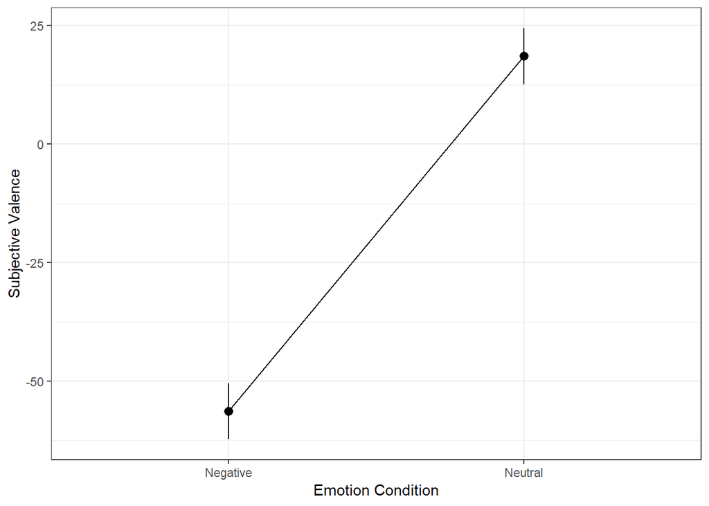

```r
library(ggplot2)

ggplot(results$means, aes(x=Emotion_Condition, y=Mean, group=1)) +
  geom_line() +
  geom_pointrange(aes(ymin=CI_lower, ymax=CI_higher)) +
  ylab("Subjective Valence") +
  xlab("Emotion Condition") +
  theme_bw()
```

### Interakcje

Let’s repeat the previous steps with adding the participant’s sex as a predictor.

```r
fit <- lmer(Subjective_Valence ~ Emotion_Condition * Participant_Sex + (1|Participant_ID), data=emotion)
anova(fit)
```

```
## Type III Analysis of Variance Table with Satterthwaite's method
##                                   Sum Sq Mean Sq NumDF DenDF  F value
## Emotion_Condition                 703963  703963     1   891 621.8068
## Participant_Sex                      520     520     1    17   0.4593
## Emotion_Condition:Participant_Sex  20496   20496     1   891  18.1041
##                                      Pr(>F)
## Emotion_Condition                 < 2.2e-16 ***
## Participant_Sex                      0.5071
## Emotion_Condition:Participant_Sex 2.313e-05 ***
## ---
## Signif. codes:  0 '***' 0.001 '**' 0.01 '*' 0.05 '.' 0.1 ' ' 1
```

It seems that there is a significant main effect of the emotion condition, as well as an interaction with the participants’ sex. Let’s plot the estimated means.

```r
results2 <- get_contrasts(fit, "Emotion_Condition * Participant_Sex")
print(results2$means)
```

```
##   Emotion_Condition Participant_Sex      Mean       SE       df
## 1          Negative          Female -59.73080 3.280003 23.30494
## 2           Neutral          Female  20.04585 3.280003 23.30494
## 3          Negative            Male -43.62600 6.351698 23.30494
## 4           Neutral            Male  12.89408 6.351698 23.30494
##      CI_lower CI_higher
## 1 -66.5110961 -52.95051
## 2  13.2655523  26.82614
## 3 -56.7559761 -30.49601
## 4  -0.2359003  26.02406
```

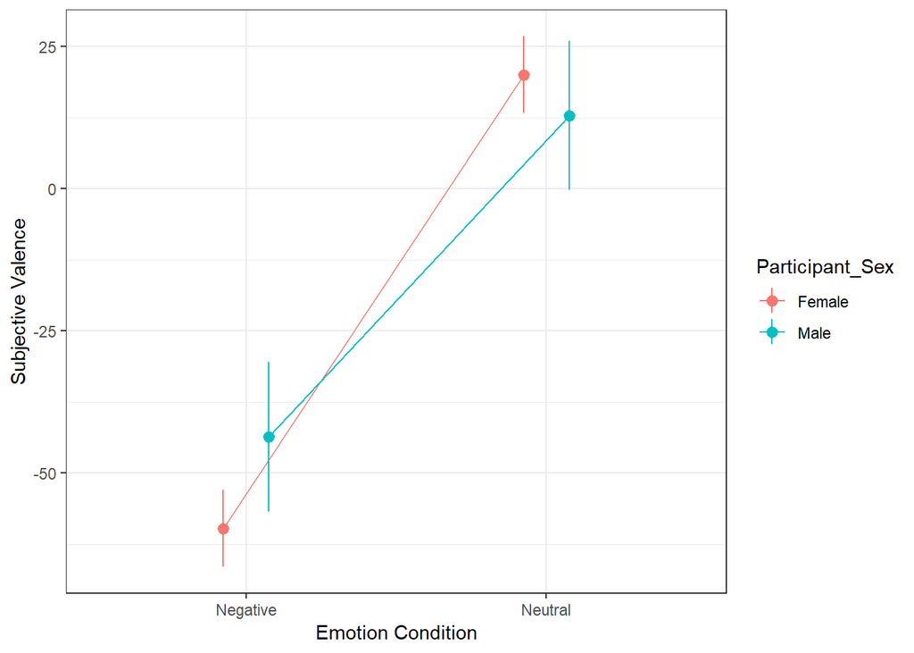

```r
ggplot(results2$means, aes(x=Emotion_Condition, y=Mean, color=Participant_Sex, group=Participant_Sex)) +
  geom_line(position = position_dodge(.3)) +
  geom_pointrange(aes(ymin=CI_lower, ymax=CI_higher),
                  position = position_dodge(.3)) +
  ylab("Subjective Valence") +
  xlab("Emotion Condition") +
  theme_bw()
```

```r
print(results2$contrasts)
```

```
##                           Contrast Difference       SE        df
## 1 Negative,Female - Neutral,Female -79.776648 2.507904 891.00000
## 2  Negative,Female - Negative,Male -16.104808 7.148600  23.30494
## 3   Negative,Female - Neutral,Male -72.624884 7.148600  23.30494
## 4   Neutral,Female - Negative,Male  63.671841 7.148600  23.30494
## 5    Neutral,Female - Neutral,Male   7.151765 7.148600  23.30494
## 6     Negative,Male - Neutral,Male -56.520076 4.856535 891.00000
##      t.ratio      p.value
## 1 -31.810091 0.000000e+00
## 2  -2.252862 1.386356e-01
## 3 -10.159316 2.868312e-09
## 4   8.906897 3.347341e-08
## 5   1.000443 7.506245e-01
## 6 -11.637943 0.000000e+00
```

It appears that the differences between men and women is not significant. However, by default, get_contrasts uses the Tukey method for p value adjustment. We can, with an exploratory mindset, turn off the p value correction (or choose other methods such as bonferonni, fdr and such).

```r
results <- get_contrasts(fit, "Emotion_Condition * Participant_Sex", adjust = "none")
print(results$contrasts)
```

```
##                           Contrast Difference       SE        df
## 1 Negative,Female - Neutral,Female -79.776648 2.507904 891.00000
## 2  Negative,Female - Negative,Male -16.104808 7.148600  23.30494
## 3   Negative,Female - Neutral,Male -72.624884 7.148600  23.30494
## 4   Neutral,Female - Negative,Male  63.671841 7.148600  23.30494
## 5    Neutral,Female - Neutral,Male   7.151765 7.148600  23.30494
## 6     Negative,Male - Neutral,Male -56.520076 4.856535 891.00000
##      t.ratio       p.value
## 1 -31.810091 5.703483e-149
## 2  -2.252862  3.397484e-02
## 3 -10.159316  4.930633e-10
## 4   8.906897  5.781252e-09
## 5   1.000443  3.273715e-01
## 6 -11.637943  3.052226e-29
```

Without correcting for multiple comparisons, we observe that men rate the negative pictures as significantly less negative than women.